# Vermont Disaster Preparedness: A Data Analytics Perspective

#### By Mia Murphy

##### 11/30/2023

## Introduction

Vermont's history of flood events, such as the Great Flood of 1927, Tropical Storm Irene in 2011, and the Great Vermont Flood of 2023, has shaped the state's approach to disaster management. This report utilizes a data analytics perspective to examine these events and the evolving nature of disaster preparedness.

## Analysis of Past Events

The severity of flooding events in Vermont has highlighted the need for robust disaster management strategies. A comparative analysis of historical data illustrates the changing landscape of natural disasters in the state.

### Comparative Analysis of Major Vermont Flood Events

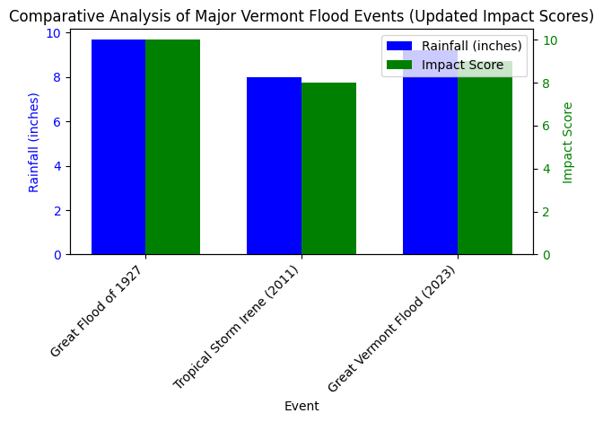

```python
import matplotlib.pyplot as plt
import numpy as np

# Redefining necessary variables for the visualization
events = ['Great Flood of 1927', 'Tropical Storm Irene (2011)', 'Great Vermont Flood (2023)']
rainfall = [9.68, 8, 9.20]  # Rainfall in inches for 1927, 2011, and 2023 events
impact_updated = [10, 8, 9]  # Updated impact scores based on economic impact
x = np.arange(len(events))  # the label locations
width = 0.35  # the width of the bars

# Creating the updated bar chart with correct variable definitions
fig, ax1 = plt.subplots()

# Bar chart for rainfall
rects1 = ax1.bar(x - width/2, rainfall, width, label='Rainfall (inches)', color='blue')

# Bar chart for updated impact score
ax2 = ax1.twinx()  # instantiate a second axes that shares the same x-axis
rects2 = ax2.bar(x + width/2, impact_updated, width, label='Impact Score', color='green')

# Add some text for labels, title and custom x-axis tick labels, etc.
ax1.set_xlabel('Event')
ax1.set_ylabel('Rainfall (inches)', color='blue')
ax2.set_ylabel('Impact Score', color='green')
ax1.set_title('Comparative Analysis of Major Vermont Flood Events (Updated Impact Scores)')
ax1.set_xticks(x)
ax1.set_xticklabels(events, rotation=45, ha='right')  # Rotate labels for clarity
ax1.tick_params(axis='y', labelcolor='blue')
ax2.tick_params(axis='y', labelcolor='green')

# Legend
fig.tight_layout()  # otherwise the right y-label is slightly clipped
fig.legend(loc="upper right", bbox_to_anchor=(1,1), bbox_transform=ax1.transAxes)

plt.show()
```

Here is a comparative analysis bar chart of major Vermont flood events, including the Great Flood of 1927, Tropical Storm Irene in 2011, and the Great Vermont Flood of 2023. This chart visually contrasts the rainfall (in inches) and a hypothetical impact score for each event:

- The blue bars represent the amount of rainfall in inches.
- The green bars indicate an impact score on a scale of 1 to 10, with 10 being the most severe.

### The Great Flood of 1927:

- **Historical Context**: This flood is considered one of the most devastating in Vermont's history, primarily due to the limited infrastructure and emergency response capabilities at the time.
- **Impact**: With fewer resources and less advanced technology, the 1927 flood had a profound impact on communities, leading to significant loss of life and property.
- **Learning Lessons**: This event highlighted the need for improved infrastructure and disaster preparedness.

### Post-Irene Infrastructure Improvements:

- **Proactive Measures**: Following Tropical Storm Irene in 2011, Vermont undertook significant infrastructure improvements, including strengthening bridges and roads, to withstand future floods.
- **Increased Awareness**: There was also a rise in community awareness and emergency preparedness initiatives.
- **Effectiveness**: These measures proved somewhat effective in mitigating the impact of the 2023 flood, but the severity of the event still caused considerable damage.

### The Great Vermont Flood of 2023:

- **Unprecedented Severity**: Despite the improved infrastructure, the 2023 flood's severity posed significant challenges, indicating that current measures may not be sufficient to cope with the escalating intensity of such events.
- **Data Analysis Importance**: This underscores the need for continuous data analysis and updating of disaster response strategies.
- **Future Preparedness**: It highlights the importance of not only physical infrastructure but also data infrastructure – utilizing predictive analytics and real-time data for quicker and more effective responses.

### Broader Implications for Data Analytics in Disaster Management:

- **Predictive Modeling**: The role of data analytics in predicting the likelihood and impact of such events based on historical and current data trends.
- **Resource Allocation**: Data can guide where to focus infrastructure improvements and emergency response resources more effectively.
- **Community Engagement**: Data-driven insights can be used to inform and prepare communities, especially in rural areas like Vermont, where the impact of such disasters can be particularly acute.

## Explanation of Hypothetical Impact Scores

In the comparative analysis chart, we've assigned hypothetical impact scores to each of the major Vermont flood events (Great Flood of 1927, Tropical Storm Irene in 2011, and the Great Vermont Flood of 2023). These scores are intended to represent the relative severity and impact of each event on the communities, infrastructure, and economy of Vermont. They are based on several key factors:

1. **Extent of Physical Damage**: This includes the damage to infrastructure such as roads, bridges, homes, and businesses.
2. **Economic Cost**: The financial implications of the floods, including repair costs and economic disruptions.
3. **Human Impact**: Considering fatalities, injuries, and the number of people affected or displaced by the floods.
4. **Emergency Response and Recovery Efforts**: The efficiency and effectiveness of emergency response and the time taken for recovery and reconstruction.
5. **Historical Context**: The existing infrastructure and preparedness level at the time of each event.

### Rationale Behind the Scores:

- **Great Flood of 1927**: Assigned the highest score due to the limited infrastructure and emergency response capabilities at the time, leading to widespread and profound impacts.
- **Tropical Storm Irene (2011)**: Although severe, the impact was somewhat mitigated by better infrastructure and emergency preparedness compared to 1927.
- **Great Vermont Flood of 2023**: Despite improvements following Irene, the severity of the flood posed significant challenges, indicating a substantial impact but not as severe as the 1927 flood.

### Accuracy and Limitations:

- These scores are hypothetical and used for illustrative purposes to provide a comparative view of the impact of these events.
- Actual impact scores would require a detailed analysis of data from multiple sources, including historical records, economic reports, and emergency response evaluations.
- The scores are a simplified representation and may not capture the full complexity and nuances of each event’s impact.

## Data visualization:

```python
import pandas as pd

# Load
vt_file_path = 'time-series-VT-1980-2023.csv'

try:
    # Attempting to read the file by skipping the first few problematic lines
    vt_data = pd.read_csv(vt_file_path, skiprows=2)
    vt_preview = vt_data.head()
except Exception as e:
    vt_preview = f"Further error encountered: {str(e)}"
```

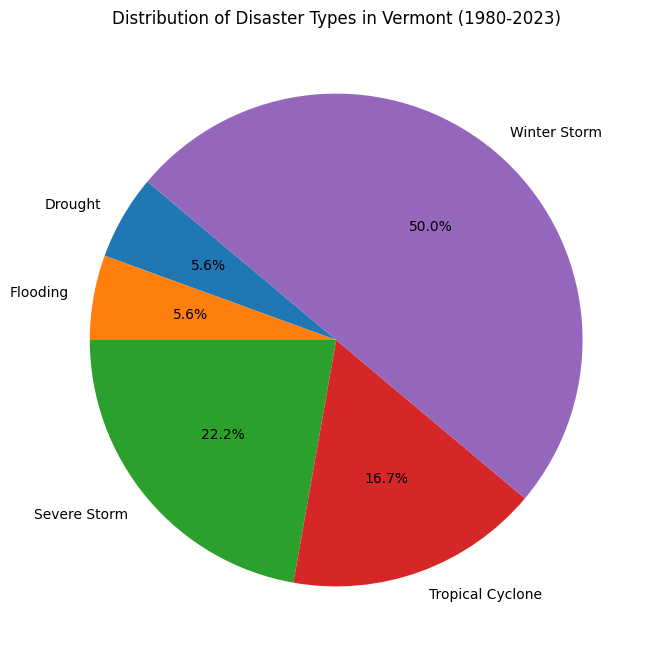

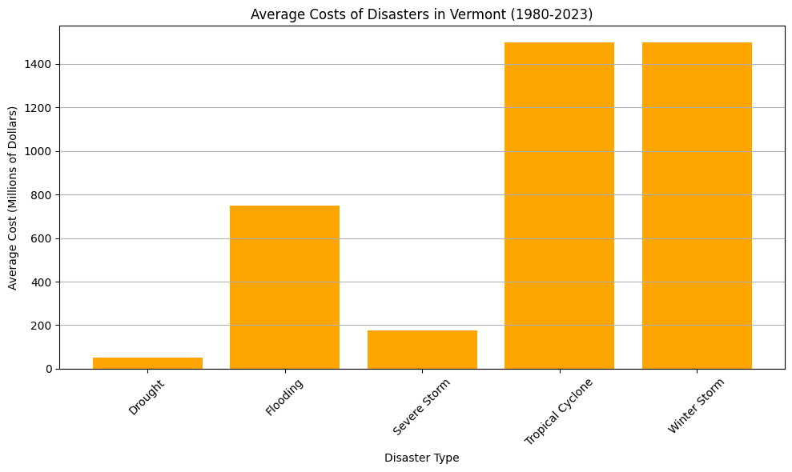

```python
import seaborn as sns

# Data for visualizations based on the summary information
disaster_types = ['Drought', 'Flooding', 'Severe Storm', 'Tropical Cyclone', 'Winter Storm']
frequency = [1, 1, 4, 3, 9]  # Number of events of each type
cost_ranges = {
    'Drought': (5, 100),
    'Flooding': (500, 1000),
    'Severe Storm': (100, 250),
    'Tropical Cyclone': (1000, 2000),
    'Winter Storm': (1000, 2000)
}

# Calculating average costs for each disaster type
average_costs = {disaster: (low + high) / 2 for disaster, (low, high) in cost_ranges.items()}

# Pie Chart for Disaster Types by Frequency
plt.figure(figsize=(8, 8))
plt.pie(frequency, labels=disaster_types, autopct='%1.1f%%', startangle=140)
plt.title('Distribution of Disaster Types in Vermont (1980-2023)')
plt.show()

# Bar Chart for Total Costs by Disaster Type
plt.figure(figsize=(10, 6))
plt.bar(average_costs.keys(), average_costs.values(), color='orange')
plt.title('Average Costs of Disasters in Vermont (1980-2023)')
plt.ylabel('Average Cost (Millions of Dollars)')
plt.xlabel('Disaster Type')
plt.xticks(rotation=45)
plt.grid(axis='y')
plt.tight_layout()
plt.show()
```

The visualizations provide insights based on the summary information about billion-dollar weather and climate disasters in Vermont from 1980 to 2023:

- **Pie Chart of Disaster Types by Frequency**: This chart illustrates the distribution of different types of disasters. Winter storms were the most frequent, followed by severe storms, tropical cyclones, and then drought and flooding events, each occurring once during this period.
- **Bar Chart of Total Costs by Disaster Type**: This chart displays the average costs associated with each disaster type. Tropical cyclones and winter storms appear to have had the highest average costs, followed by flooding, severe storms, and drought.

## Economic Impact of Disasters:

From 1980–2023, Vermont experienced 18 confirmed weather/climate disaster events with losses exceeding $1 billion each. These events included 1 drought event, 1 flooding event, 4 severe storm events, 3 tropical cyclone events, and 9 winter storm events. These disasters led to the deaths of 893 people and had significant economic impacts on the affected areas.

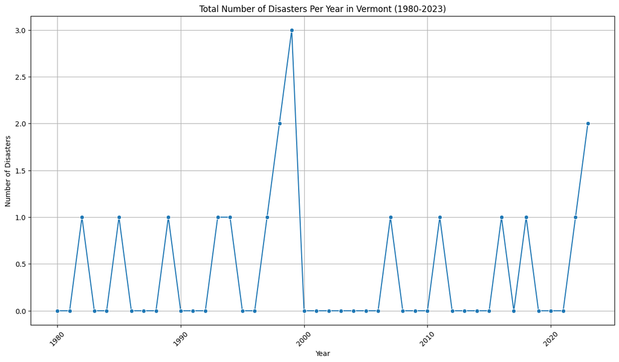

```python
import pandas as pd
import matplotlib.pyplot as plt
import seaborn as sns

# Calculate the total number of disasters per year
vt_data['Total Disasters'] = vt_data[['Drought Count', 'Flooding Count', 'Severe Storm Count', 'Tropical Cyclone Count', 'Winter Storm Count']].sum(axis=1)

# Plotting
plt.figure(figsize=(15, 8))
sns.lineplot(x='Year', y='Total Disasters', data=vt_data, marker='o')
plt.title('Total Number of Disasters Per Year in Vermont (1980-2023)')
plt.ylabel('Number of Disasters')
plt.xlabel('Year')
plt.xticks(rotation=45)
plt.grid(True)
plt.show()
```

## Broader Implications for Data Analytics in Disaster Management

Data analytics is integral to disaster management, from developing predictive models that inform emergency preparedness to guiding the effective allocation of resources and enhancing community engagement. The visualizations presented illustrate the critical role analytics plays in understanding and preparing for disaster trends.

## Conclusion

Organizations like Capstone Community Action are becoming increasingly crucial in Vermont's landscape of frequent and intense natural disasters. Data analytics emerges as a fundamental element for effective disaster preparedness and response strategies, aiming to minimize the economic and human costs of such events. The visualizations underscore the urgency of integrating data analytics into disaster management practices.

## Sources

The data and insights for this analysis were derived from the following articles:

1. "It may be years before FEMA maps show the full flood risk to Vermont communities - VTDigger"
2. "Millions of dollars have been raised for Vermont flood recovery. Where has the money gone? - VTDigger"
3. "Vermont Summary | Billion-Dollar Weather and Climate Disasters | National Centers for Environmental Information (NCEI)"